# Text Processing Presentation

Stephanie Gluck & Pooya Razavi

5/3/2018

# Introduction

This presentation aims to introduce a very brief summary on general manipulation of character strings and text data. We will cover string manipulations using the package `stringr` and some functions from base R, along with how regular expression can be applied to pattern matching. We will also introduce text analysis examples using the package `tidytext`.

As we will barely scratch the surface of strings, regular expression and text analysis, a resources section is available at the end of the presentation.

Reference

Anderson, D. (2017). *EDLD610 - Exploring Data with R*

## Why?

Even if you don’t frequently conduct text analysis or text mining, character strings manipuliaton is useful for data wrangling:

- You want to remove a given character in the names of your variables
- You want to replace a given character in your data
- You want to convert labels to upper case (or lower case)
- You want to subset your data based on a specific pattern (e.g., extract phone numbers from a messy survey, 541-346-1234, 541.346.1234, 541-3461234, work: 541-3461234)
- and more!

# String Manipulations

We will cover the `stringr` package and some functions from base R.

The [stringr](http://r4ds.had.co.nz/strings.html) package is part of tidyverse but many of the base R function are common enough to warrant some introduciton.

Strings can be anything wrapped in quotes, such as:

```r
c("TRUE",
"7",
"z",
"3.14",
"pooya")
```

```
## [1] "TRUE"  "7"     "z"     "3.14"  "pooya"
```

The `stringr` package contains built-in datasets we’ll be using as examples today such as:

```r
head(fruit)
```

```
## [1] "apple"       "apricot"     "avocado"     "banana"      "bell pepper"
## [6] "bilberry"
```

```r
head(sentences)
```

```
## [1] "The birch canoe slid on the smooth planks."
## [2] "Glue the sheet to the dark blue background."
## [3] "It's easy to tell the depth of a well."
## [4] "These days a chicken leg is a rare dish."
## [5] "Rice is often served in round bowls."
## [6] "The juice of lemons makes fine punch."
```

```r
head(words)
```

```
## [1] "a"        "able"     "about"    "absolute" "accept"   "account"
```

## String manipulations in R and stringr

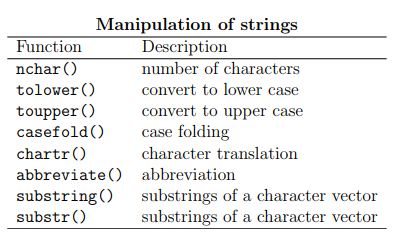

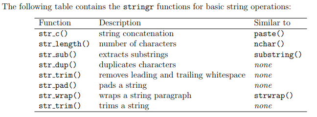

From Handling and Processing Strings in R [Sanchez, 2013](http://www.gastonsanchez.com/Handling_and_Processing_Strings_in_R.pdf)

## Upper, lower, & title case

```r
#stringr
str_to_upper(fruit) %>% head()
```

```
## [1] "APPLE"       "APRICOT"     "AVOCADO"     "BANANA"      "BELL PEPPER"
## [6] "BILBERRY"
```

```r
str_to_lower(fruit) %>% head()
```

```
## [1] "apple"       "apricot"     "avocado"     "banana"      "bell pepper"
## [6] "bilberry"
```

```r
#to title case in stringr
head(sentences)
```

```
## [1] "The birch canoe slid on the smooth planks."
## [2] "Glue the sheet to the dark blue background."
## [3] "It's easy to tell the depth of a well."
## [4] "These days a chicken leg is a rare dish."
## [5] "Rice is often served in round bowls."
## [6] "The juice of lemons makes fine punch."
```

```r
str_to_title(sentences) %>% head()
```

```
## [1] "The Birch Canoe Slid On The Smooth Planks."
## [2] "Glue The Sheet To The Dark Blue Background."
## [3] "It's Easy To Tell The Depth Of A Well."
## [4] "These Days A Chicken Leg Is A Rare Dish."
## [5] "Rice Is Often Served In Round Bowls."
## [6] "The Juice Of Lemons Makes Fine Punch."
```

```r
#base
toupper(fruit) %>% head()
```

```
## [1] "APPLE"       "APRICOT"     "AVOCADO"     "BANANA"      "BELL PEPPER"
## [6] "BILBERRY"
```

```r
tolower(fruit) %>% head()
```

```
## [1] "apple"       "apricot"     "avocado"     "banana"      "bell pepper"
## [6] "bilberry"
```

```r
#to title case in base, uses the pre-installed tools package
tools::toTitleCase(sentences) %>% head()
```

```
## [1] "The Birch Canoe Slid on the Smooth Planks."
## [2] "Glue the Sheet to the Dark Blue Background."
## [3] "It's Easy to Tell the Depth of a Well."
## [4] "These Days a Chicken Leg is a Rare Dish."
## [5] "Rice is Often Served in Round Bowls."
## [6] "The Juice of Lemons Makes Fine Punch."
```

## Joining strings

```r
#stringr
str_c("red", "apple")
```

```
## [1] "redapple"
```

```r
str_c("red", "apple", sep = " ")
```

```
## [1] "red apple"
```

```r
str_c("red", "apple", sep = " : ")
```

```
## [1] "red : apple"
```

```r
#base
paste0("red", "apple")
```

```
## [1] "redapple"
```

```r
paste("red", "apple")
```

```
## [1] "red apple"
```

```r
paste("red", "apple", sep = " : ")
```

```
## [1] "red : apple"
```

## String length

```r
fruit[1:3]
```

```
## [1] "apple"   "apricot" "avocado"
```

```r
#stringr
str_length(fruit[1:3])
```

```
## [1] 5 7 7
```

```r
#base
nchar(fruit[1:3])
```

```
## [1] 5 7 7
```

## Subset strings

Subset strings in stringr

```r
#stringr

fruit[1:5]
```

```
## [1] "apple"       "apricot"     "avocado"     "banana"      "bell pepper"
```

```r
#return first 3 and print rest
str_sub(fruit[1:5], 3)
```

```
## [1] "ple"       "ricot"     "ocado"     "nana"      "ll pepper"
```

```r
#only return character 3 to 6, includes spaces
str_sub(fruit[1:5], 3, 6)
```

```
## [1] "ple"  "rico" "ocad" "nana" "ll p"
```

```r
nchar(fruit[1:5])
```

```
## [1]  5  7  7  6 11
```

```r
#return last 3 character
str_sub(fruit[1:5], -3)
```

```
## [1] "ple" "cot" "ado" "ana" "per"
```

Subset strings in base

```r
#in base, needs to provide a stop argument
substr(fruit[1:5], 3, nchar(fruit[1:5]))
```

```
## [1] "ple"       "ricot"     "ocado"     "nana"      "ll pepper"
```

```r
#this will generate an error
#substr(fruit[1:5], 3)

#the stop argument is 6
substr(fruit[1:5], 3, 6)
```

```
## [1] "ple"  "rico" "ocad" "nana" "ll p"
```

```r
#count number of character minus 2, and return character until end of string
substr(fruit[1:5], nchar(fruit[1:5]) - 2, nchar(fruit[1:5]))
```

```
## [1] "ple" "cot" "ado" "ana" "per"
```

## Modify strings

Use `str_sub` to modify strings

```r
fruit[1:5]
```

```
## [1] "apple"       "apricot"     "avocado"     "banana"      "bell pepper"
```

```r
#extract second to fourth character and replace with XX
replaced_fruit <- str_sub(fruit[1:5])
str_sub(replaced_fruit[1:5], 2, 4) <- "XX"
replaced_fruit
```

```
## [1] "aXXe"       "aXXcot"     "aXXado"     "bXXna"      "bXX pepper"
```

```r
#notice that we specified to subset 3 characters but only replaced it with 2 characters
```

## Locate where strings occur

```r
fruit[c(1:5, 60:65)] %>%
  str_locate("ap")
```

```
##       start end
##  [1,]     1   2
##  [2,]     1   2
##  [3,]    NA  NA
##  [4,]    NA  NA
##  [5,]    NA  NA
##  [6,]    NA  NA
##  [7,]    NA  NA
##  [8,]     5   6
##  [9,]    NA  NA
## [10,]    NA  NA
## [11,]    NA  NA
```

```r
fruit[c(1:5, 60:65)] %>%
  str_locate("apple")
```

```
##       start end
##  [1,]     1   5
##  [2,]    NA  NA
##  [3,]    NA  NA
##  [4,]    NA  NA
##  [5,]    NA  NA
##  [6,]    NA  NA
##  [7,]    NA  NA
##  [8,]     5   9
##  [9,]    NA  NA
## [10,]    NA  NA
## [11,]    NA  NA
```

## Trim and pad white space

```r
white_space <- c(" before", "after "," both ")
white_space
```

```
## [1] " before" "after "  " both "
```

```r
str_trim(white_space)
```

```
## [1] "before" "after"  "both"
```

```r
pad_space <- c("abc", "acbdefg")
#10 specifies the number of total characters you want in your string, and if it has less than the specified target, it will pad spaces until the target value is reached
str_pad(pad_space, 10)
```

```
## [1] "       abc" "   acbdefg"
```

```r
str_pad(pad_space, 10, side = "right")
```

```
## [1] "abc       " "acbdefg   "
```

```r
str_pad(pad_space, 10, side = "both")
```

```
## [1] "   abc    " " acbdefg  "
```

## Pad with something else

```r
string_nums <- as.character(1:15)
string_nums
```

```
##  [1] "1"  "2"  "3"  "4"  "5"  "6"  "7"  "8"  "9"  "10" "11" "12" "13" "14"
## [15] "15"
```

```r
str_pad(string_nums, 3, pad = "0")
```

```
##  [1] "001" "002" "003" "004" "005" "006" "007" "008" "009" "010" "011"
## [12] "012" "013" "014" "015"
```

# Regular Expression

Regular expression is an “instruction” (or pattern) given to a function on what and how to match or replace strings (Eden, 2007).

We will briefly touch upon some regular expression with examples and provide resources for references at the end of the presentation.

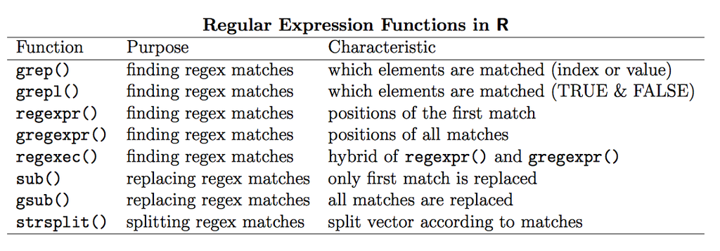

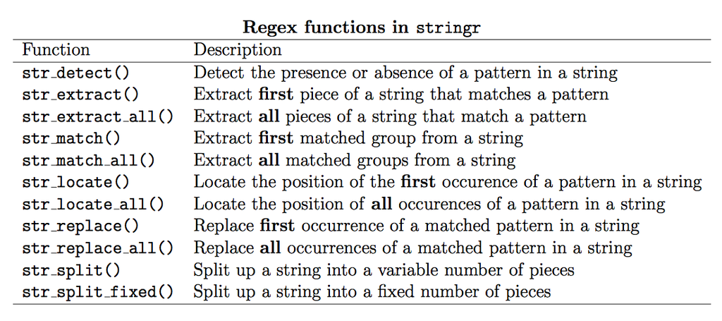

stringr provides pattern matching functions to detect, locate, extract, match, replace, and split strings.

from Handling and Processing Strings in R, [Sanchez, 2013](http://www.gastonsanchez.com/Handling_and_Processing_Strings_in_R.pdf)

**Regular expression can be used to:**

- identify match to a pattern: `grep(..., value = FALSE)`, `grepl()`, `stringr::str_detect()`
- extract match to a pattern: `grep(..., value = TRUE)`, `stringr::str_extract()`, `stringr::str_extract_all()`
- locate pattern within a string, e.g., give the start position of matched patterns. `regexpr()`, `gregexpr()`, `stringr::str_locate()`, `string::str_locate_all()`
- replace a pattern: `sub()`, `gsub()`, `stringr::str_replace()`, `stringr::str_replace_all()`
- split a string using a pattern: `strsplit()`, `stringr::str_split()`

## Locate pattern

A helpful function when learning to locate pattern is the `str_view` which allows you to see what R is doing behind the scene This requires the `htmlwidgets` pacakge

```r
str_view(sentences[1:5], "the")
```

[interactive chart not shown]

```r
str_view(fruit[1:5], "ap")
```

[interactive chart not shown]

Search for a particular pattern in each element of a vector x. grep(pattern, x)

```r
#let's find the location of all the sentences with the word "boy"
grep("boy", sentences)
```

```
## [1]  11  25 423 591 634 663 708
```

```r
sentences[c(11, 423)]
```

```
## [1] "The boy was there when the sun rose."
## [2] "The boy owed his pal thirty cents."
```

## Extract sentence

```r
#this will return all sentences that contains the string "red"
str_subset(sentences, "red")
```

```
##  [1] "The colt reared and threw the tall rider."
##  [2] "The wide road shimmered in the hot sun."
##  [3] "See the cat glaring at the scared mouse."
##  [4] "He ordered peach pie with ice cream."
##  [5] "Pure bred poodles have curls."
##  [6] "Mud was spattered on the front of his white shirt."
##  [7] "The sofa cushion is red and of light weight."
##  [8] "Torn scraps littered the stone floor."
##  [9] "The doctor cured him with these pills."
## [10] "The new girl was fired today at noon."
## [11] "The third act was dull and tired the players."
## [12] "Lire wires should be kept covered."
## [13] "It is hard to erase blue or red ink."
## [14] "The wreck occurred by the bank on Main Street."
## [15] "The box is held by a bright red snapper."
```

[output cut: 25 more lines]

```r
#value = TRUE, returns the matching elements themselves instead of location when value = FALSE
grep("red", sentences, value = TRUE)
```

```
##  [1] "The colt reared and threw the tall rider."
##  [2] "The wide road shimmered in the hot sun."
##  [3] "See the cat glaring at the scared mouse."
##  [4] "He ordered peach pie with ice cream."
##  [5] "Pure bred poodles have curls."
##  [6] "Mud was spattered on the front of his white shirt."
##  [7] "The sofa cushion is red and of light weight."
##  [8] "Torn scraps littered the stone floor."
##  [9] "The doctor cured him with these pills."
## [10] "The new girl was fired today at noon."
## [11] "The third act was dull and tired the players."
## [12] "Lire wires should be kept covered."
## [13] "It is hard to erase blue or red ink."
## [14] "The wreck occurred by the bank on Main Street."
## [15] "The box is held by a bright red snapper."
```

[output cut: 25 more lines]

```r
#with regular expression \\w - match a word character
#\\W - match a non word character
str_subset(sentences, "\\w red")
```

```
##  [1] "The sofa cushion is red and of light weight."
##  [2] "It is hard to erase blue or red ink."
##  [3] "The box is held by a bright red snapper."
##  [4] "The houses are built of red clay bricks."
##  [5] "The red tape bound the smuggled food."
##  [6] "The lake sparkled in the red hot sun."
##  [7] "Mark the spot with a sign painted red."
##  [8] "The small red neon lamp went out."
##  [9] "The sky in the west is tinged with orange red."
## [10] "The red paper brightened the dim stage."
## [11] "The big red apple fell to the ground."
```

## Count occurences

```r
#returns the number of "the" in the first 100 sentences
str_count(sentences, "the")[1:100]
```

```
##   [1] 1 2 1 0 0 0 1 0 0 0 2 0 2 1 1 1 0 1 1 1 1 1 2 0 2 1 0 1 1 0 1 2 2 1 1
##  [36] 0 0 0 1 1 2 1 1 1 1 2 1 1 1 0 1 1 0 1 0 0 2 0 1 2 2 1 1 1 1 0 1 1 2 2
##  [71] 2 1 1 0 0 0 2 0 0 0 1 2 0 0 0 1 1 0 1 0 1 1 0 1 0 1 0 0 0 0
```

## Logical tests

```r
#good to use in filter
str_detect(sentences, "the")[1:100]
```

```
##   [1]  TRUE  TRUE  TRUE FALSE FALSE FALSE  TRUE FALSE FALSE FALSE  TRUE
##  [12] FALSE  TRUE  TRUE  TRUE  TRUE FALSE  TRUE  TRUE  TRUE  TRUE  TRUE
##  [23]  TRUE FALSE  TRUE  TRUE FALSE  TRUE  TRUE FALSE  TRUE  TRUE  TRUE
##  [34]  TRUE  TRUE FALSE FALSE FALSE  TRUE  TRUE  TRUE  TRUE  TRUE  TRUE
##  [45]  TRUE  TRUE  TRUE  TRUE  TRUE FALSE  TRUE  TRUE FALSE  TRUE FALSE
##  [56] FALSE  TRUE FALSE  TRUE  TRUE  TRUE  TRUE  TRUE  TRUE  TRUE FALSE
##  [67]  TRUE  TRUE  TRUE  TRUE  TRUE  TRUE  TRUE FALSE FALSE FALSE  TRUE
##  [78] FALSE FALSE FALSE  TRUE  TRUE FALSE FALSE FALSE  TRUE  TRUE FALSE
##  [89]  TRUE FALSE  TRUE  TRUE FALSE  TRUE FALSE  TRUE FALSE FALSE FALSE
## [100] FALSE
```

```r
grepl("the", sentences)[1:100]
```

```
##   [1]  TRUE  TRUE  TRUE FALSE FALSE FALSE  TRUE FALSE FALSE FALSE  TRUE
##  [12] FALSE  TRUE  TRUE  TRUE  TRUE FALSE  TRUE  TRUE  TRUE  TRUE  TRUE
##  [23]  TRUE FALSE  TRUE  TRUE FALSE  TRUE  TRUE FALSE  TRUE  TRUE  TRUE
##  [34]  TRUE  TRUE FALSE FALSE FALSE  TRUE  TRUE  TRUE  TRUE  TRUE  TRUE
##  [45]  TRUE  TRUE  TRUE  TRUE  TRUE FALSE  TRUE  TRUE FALSE  TRUE FALSE
##  [56] FALSE  TRUE FALSE  TRUE  TRUE  TRUE  TRUE  TRUE  TRUE  TRUE FALSE
##  [67]  TRUE  TRUE  TRUE  TRUE  TRUE  TRUE  TRUE FALSE FALSE FALSE  TRUE
##  [78] FALSE FALSE FALSE  TRUE  TRUE FALSE FALSE FALSE  TRUE  TRUE FALSE
##  [89]  TRUE FALSE  TRUE  TRUE FALSE  TRUE FALSE  TRUE FALSE FALSE FALSE
## [100] FALSE
```

## Filter with str_detect

An example that uses filter with str_detect

```r
#create a hypothetical dataset
P_ID <- 1:50
num_fruit <- abs(round(rnorm(50, 3, 2),0))
type_fruit <- rep(fruit[1:50])
fruit_eaters <- as.data.frame(cbind(P_ID, num_fruit, type_fruit)) %>%
  mutate(type_fruit = as.character(type_fruit))
head(fruit_eaters)
```

```
##   P_ID num_fruit  type_fruit
## 1    1         1       apple
## 2    2         2     apricot
## 3    3         5     avocado
## 4    4         4      banana
## 5    5         2 bell pepper
## 6    6         1    bilberry
```

```r
#filter for berry eater
berry_eaters <- filter(fruit_eaters, str_detect(type_fruit, "berry"))
berry_eaters
```

```
##    P_ID num_fruit  type_fruit
## 1     6         1    bilberry
## 2     7         1  blackberry
## 3    10         4   blueberry
## 4    11         1 boysenberry
## 5    19         1  cloudberry
## 6    21         3   cranberry
## 7    29         3  elderberry
## 8    32         5  goji berry
## 9    33         2  gooseberry
## 10   38         3 huckleberry
## 11   50         5    mulberry
```

Metacharacters are special characters that define specific operations

Regular expressions typically specify characters (or character classes) to seek out, possibly with information about repeats and location within the string. This is accomplished with the help of metacharacters that have specific meaning: `$ * + . ? [ ] ^ { } | ( ) \.`

**Quantifier Matching**

Specify how many repetitions of the pattern.

`*`: matches at least 0 times.

`+`: matches at least 1 times.

`?`: matches at most 1 times.

`{n}`: matches exactly n times.

`{n,}`: matches at least n times.

`{n,m}`: matches between n and m times.

## Quantifier matching

```r
strings <- c("a", "ab", "acb", "accb", "acccb", "accccb")

#we are applying the quantifier to c
#return everything with a & b
grep("ac*b", strings, value = TRUE) #disregarding the amount of c
```

```
## [1] "ab"     "acb"    "accb"   "acccb"  "accccb"
```

```r
grep("ac+b", strings, value = TRUE) #with at least 1 c
```

```
## [1] "acb"    "accb"   "acccb"  "accccb"
```

```r
grep("ac?b", strings, value = TRUE) #with at most 1 c
```

```
## [1] "ab"  "acb"
```

```r
grep("ac{2}b", strings, value = TRUE) #with exactly 2 c
```

```
## [1] "accb"
```

**Position Matching**

Matches position of pattern within the string

`^`: matches the start of the string.

`$`: matches the end of the string.

`\b`: matches the empty string at either edge of a word. Donât confuse it with ^ $ which marks the edge of a string.

`\B`: matches the empty string provided it is not at an edge of a word.

## Position Matching

```r
itemIDs <- c("RF3L02E03", "RF3M08E05", "RF3H10E08", "RL1L03E03", "RL1M05E05", "RL1H10E04", "RI2L03E07", "RI2M06E05", "RI2HSAMPLEE06", "WR4L02E03", "WR4M06E06", "WR4H09E03", "WR9L03E04", "WR9M08E04", "WR9H12E04", "LA1L01E11", "LA1M06E04", "LA1H09E04", "WR2L03E05", "WR2M06E05", "WR2H10E05", "LA2LSAMPLEE03", "LA2M06E04", "LA2H09E08", "RF4L02E03", "RF4M08E06", "RF4H09E07", "RL7L02E07", "RL7M06E06", "RL7H10E06", "RI1L02E07", "RI1M07E08", "RI1H11E07", "WR1L02E07", "WR1M07E07", "WR1H11E08")
# select items that ends with 4 using regex
str_subset(itemIDs, "4$")
```

```
## [1] "RL1H10E04" "WR9L03E04" "WR9M08E04" "WR9H12E04" "LA1M06E04" "LA1H09E04"
## [7] "LA2M06E04"
```

Match the start of a string

```r
#select items starting with RF
str_subset(itemIDs, "^RF")
```

```
## [1] "RF3L02E03" "RF3M08E05" "RF3H10E08" "RF4L02E03" "RF4M08E06" "RF4H09E07"
```

```r
#select items starting with WR
str_subset(itemIDs, "^WR")
```

```
##  [1] "WR4L02E03" "WR4M06E06" "WR4H09E03" "WR9L03E04" "WR9M08E04"
##  [6] "WR9H12E04" "WR2L03E05" "WR2M06E05" "WR2H10E05" "WR1L02E07"
## [11] "WR1M07E07" "WR1H11E08"
```

It is useful to include ^ metacharacter incase there are matches with the same pattern that is not at the beginning.

## Anchor Sequences

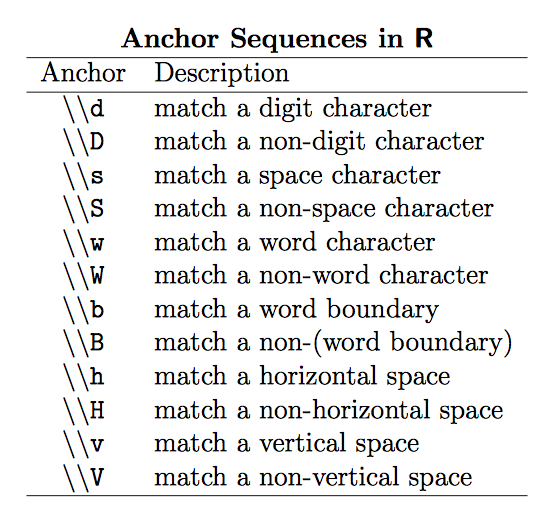

from [Sanchez, 2013](http://www.gastonsanchez.com/Handling_and_Processing_Strings_in_R.pdf)

## Digits

```r
digits <- c("Charlie", "Charlie2", "Mary", "Marianne", "Mary2", "15")

#match a digit character
str_subset(digits, "\\d") #return anything containing digits
```

```
## [1] "Charlie2" "Mary2"    "15"
```

```r
#match a non-digit character
str_subset(digits, "\\D")
```

```
## [1] "Charlie"  "Charlie2" "Mary"     "Marianne" "Mary2"
```

```r
#return anything containing non digits. Even if there is 1 nondigit character, it will be returned
```

## Spaces

```r
string <- c("School is fun. Especially recess. That's the best part. I love recess.")
#match a space character
str_replace_all(string, "\\s", "_") #replaced all spaces with "_"
```

```
## [1] "School_is_fun._Especially_recess._That's_the_best_part._I_love_recess."
```

```r
#match a non space character
str_replace_all(string, "\\S", "_") #replaced all non space with "_"
```

```
## [1] "______ __ ____ __________ _______ ______ ___ ____ _____ _ ____ _______"
```

## Words

```r
#match a word character
str_replace_all(string, "\\w", "z") #replace all characters within words with "z"
```

```
## [1] "zzzzzz zz zzz. zzzzzzzzzz zzzzzz. zzzz'z zzz zzzz zzzz. z zzzz zzzzzz."
```

```r
#match a non word character
str_replace_all(string, "\\W", "_") #replace all non word chracters with "_"
```

```
## [1] "School_is_fun__Especially_recess__That_s_the_best_part__I_love_recess_"
```

```r
#this is useful for matching a specific word in str_subset
str_subset(sentences, "red")[1:15]
```

```
##  [1] "The colt reared and threw the tall rider."
##  [2] "The wide road shimmered in the hot sun."
##  [3] "See the cat glaring at the scared mouse."
##  [4] "He ordered peach pie with ice cream."
##  [5] "Pure bred poodles have curls."
##  [6] "Mud was spattered on the front of his white shirt."
##  [7] "The sofa cushion is red and of light weight."
##  [8] "Torn scraps littered the stone floor."
##  [9] "The doctor cured him with these pills."
## [10] "The new girl was fired today at noon."
## [11] "The third act was dull and tired the players."
## [12] "Lire wires should be kept covered."
## [13] "It is hard to erase blue or red ink."
## [14] "The wreck occurred by the bank on Main Street."
## [15] "The box is held by a bright red snapper."
```

```r
str_subset(sentences, "\\w red")
```

```
##  [1] "The sofa cushion is red and of light weight."
##  [2] "It is hard to erase blue or red ink."
##  [3] "The box is held by a bright red snapper."
##  [4] "The houses are built of red clay bricks."
##  [5] "The red tape bound the smuggled food."
##  [6] "The lake sparkled in the red hot sun."
##  [7] "Mark the spot with a sign painted red."
##  [8] "The small red neon lamp went out."
##  [9] "The sky in the west is tinged with orange red."
## [10] "The red paper brightened the dim stage."
## [11] "The big red apple fell to the ground."
```

# Text Processing

We will cover basic text processing using the `tidytext` package. However, many other packages exists such as `quanteda`.

Examples are from the [Tidytext Mining with R](https://www.tidytextmining.com)

Example with some text from Emily Dickinson.

```r
text <- c("Because I could not stop for Death -",
          "He kindly stopped for me -",
          "The Carriage held but just Ourselves -",
          "and Immortality")

text
```

```
## [1] "Because I could not stop for Death -"
## [2] "He kindly stopped for me -"
## [3] "The Carriage held but just Ourselves -"
## [4] "and Immortality"
```

```r
#and convert it into a dataframe
text_df <- data_frame(line = 1:4, text = text)

text_df
```

```
## # A tibble: 4 x 2
##    line text
##   <int> <chr>
## 1     1 Because I could not stop for Death -
## 2     2 He kindly stopped for me -
## 3     3 The Carriage held but just Ourselves -
## 4     4 and Immortality
```

The tidytext package follows Tidy data principles:

- Each variable is a column
- Each observation is a row
- Each type of observational unit is a table

This means Tidytext format is a table with one-token-per-row. We need to tokenize (a.k.a. split into individual words) the text data. This is done using `unnest_toakens` in tidytext.

unnest_tokens(output, input, token = “words”)

output: Output column to be created as string or symbol.

input: Input column that gets split as string or symbol.

token: Unit for tokenizing, or a custom tokenizing function. Built-in options are “words” (default), “characters”, “character_shingles”, “ngrams”, “skip_ngrams”, “sentences”, “lines”, “paragraphs”, and “regex”

```r
text_df %>%
  unnest_tokens(word, text)
```

```
## # A tibble: 20 x 2
##     line word
##    <int> <chr>
##  1     1 because
##  2     1 i
##  3     1 could
##  4     1 not
##  5     1 stop
##  6     1 for
##  7     1 death
##  8     2 he
##  9     2 kindly
## 10     2 stopped
## 11     2 for
## 12     2 me
## 13     3 the
## 14     3 carriage
## 15     3 held
## 16     3 but
## 17     3 just
## 18     3 ourselves
## 19     4 and
## 20     4 immortality
```

After running `unnest_tokens`:

1. Punctuation has been stripped.
2. By default, `unnest_tokens()` converts the tokens to lowercase, which makes them easier to compare or combine with other datasets. (Use the `to_lower = FALSE` argument to turn off this behavior).

Now the data is in Tidy format, which allows for manipulation using tidyverse such as dplyr, tidyr, and ggplot2.

## Tidying Jane Austen’s text

We are going to import Jane Austen’s 6 completed, published novels from the `janeaustenr` package (Silge 2016), and transform them into a tidy format. The `janeaustenr` package provides these texts in a one-row-per-line format, where a line in this context is analogous to a literal printed line in a physical book. Let’s start with that, and also use mutate() to annotate a linenumber quantity to keep track of lines in the original format and a chapter (using a regex) to find where all the chapters are.

```r
original_books <- austen_books() %>%
  group_by(book) %>%
  mutate(linenumber = row_number(),
         chapter = cumsum(str_detect(text, regex("^chapter [\\divxlc]",
                                                 ignore_case = TRUE)))) %>%
  ungroup()

original_books
```

```
## # A tibble: 73,422 x 4
##    text                  book                linenumber chapter
##    <chr>                 <fct>                    <int>   <int>
##  1 SENSE AND SENSIBILITY Sense & Sensibility          1       0
##  2 ""                    Sense & Sensibility          2       0
##  3 by Jane Austen        Sense & Sensibility          3       0
##  4 ""                    Sense & Sensibility          4       0
##  5 (1811)                Sense & Sensibility          5       0
##  6 ""                    Sense & Sensibility          6       0
##  7 ""                    Sense & Sensibility          7       0
##  8 ""                    Sense & Sensibility          8       0
##  9 ""                    Sense & Sensibility          9       0
## 10 CHAPTER 1             Sense & Sensibility         10       1
## # ... with 73,412 more rows
```

Now, we need to restructure it in the one-token-per-row format using the `unnest_tokens()` function.

```r
tidy_books <- original_books %>%
  unnest_tokens(word, text)

tidy_books
```

```
## # A tibble: 725,055 x 4
##    book                linenumber chapter word
##    <fct>                    <int>   <int> <chr>
##  1 Sense & Sensibility          1       0 sense
##  2 Sense & Sensibility          1       0 and
##  3 Sense & Sensibility          1       0 sensibility
##  4 Sense & Sensibility          3       0 by
##  5 Sense & Sensibility          3       0 jane
##  6 Sense & Sensibility          3       0 austen
##  7 Sense & Sensibility          5       0 1811
##  8 Sense & Sensibility         10       1 chapter
##  9 Sense & Sensibility         10       1 1
## 10 Sense & Sensibility         13       1 the
## # ... with 725,045 more rows
```

## Removing stop words

Often in text analysis, we will want to remove stop words; stop words are words that are not useful for an analysis, typically extremely common words such as “the”, “of”, “to”, and so forth in English. We can remove stop words (kept in the tidytext dataset `stop_words`) with `anti_join()`. Anti_join return all rows from x where there are not matching values in y, keeping just columns from x.

You can also customize stop words (example further down)

```r
#If stop words is not applied
tidy_books %>%
  count(word, sort = TRUE)
```

```
## # A tibble: 14,520 x 2
##    word      n
##    <chr> <int>
##  1 the   26351
##  2 to    24044
##  3 and   22515
##  4 of    21178
##  5 a     13408
##  6 her   13055
##  7 i     12006
##  8 in    11217
##  9 was   11204
## 10 it    10234
## # ... with 14,510 more rows
```

```r
#see that the most common words are: "the", "to", "and", etc...

#apply the stop word
data(stop_words)

tidy_books <- tidy_books %>%
  anti_join(stop_words)
```

## Counting and plotting

We can also use dplyr’s `count()` to find the most common words in all the books as a whole and plot it in ggplot2.

```r
#count

tidy_books %>%
  count(word, sort = TRUE)
```

```
## # A tibble: 13,914 x 2
##    word       n
##    <chr>  <int>
##  1 miss    1855
##  2 time    1337
##  3 fanny    862
##  4 dear     822
##  5 lady     817
##  6 sir      806
##  7 day      797
##  8 emma     787
##  9 sister   727
## 10 house    699
## # ... with 13,904 more rows
```

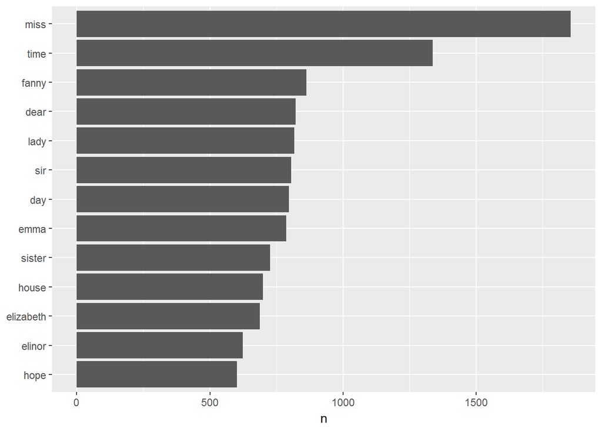

```r
#ggplot

tidy_books %>%
  count(word, sort = TRUE) %>%
  filter(n > 600) %>%
  mutate(word = reorder(word, n)) %>%
  ggplot(aes(word, n)) +
  geom_col() +
  xlab(NULL) +
  coord_flip()
```

# Sentiment Analysis

When human readers approach a text, we use our understanding of the emotional intent of words to infer whether a section of text is positive or negative, or perhaps characterized by some other more nuanced emotion like surprise or disgust. We can use the tools of text mining to approach the emotional content of text programmatically.

There are a variety of methods and dictionaries that exist for evaluating the opinion or emotion in text. The tidytext package contains several sentiment lexicons in the `sentiments` dataset.

```r
sample_n(sentiments, size = 12)
```

```
## # A tibble: 12 x 4
##    word          sentiment lexicon  score
##    <chr>         <chr>     <chr>    <int>
##  1 invincibility positive  bing        NA
##  2 appreciating  <NA>      AFINN        2
##  3 fresh         <NA>      AFINN        1
##  4 recuse        litigious loughran    NA
##  5 refused       <NA>      AFINN       -2
##  6 bacteria      negative  nrc         NA
##  7 crack         negative  nrc         NA
##  8 congress      disgust   nrc         NA
##  9 successfully  positive  loughran    NA
## 10 fancier       positive  bing        NA
## 11 satirical     negative  bing        NA
## 12 nepotism      anger     nrc         NA
```

The `nrc` lexicon categorizes words in a binary fashion (“yes”/“no”) into categories of positive, negative, anger, anticipation, disgust, fear, joy, sadness, surprise, and trust. The `bing` lexicon categorizes words in a binary fashion into positive and negative categories. The `AFINN` lexicon assigns words with a score that runs between -5 and 5, with negative scores indicating negative sentiment and positive scores indicating positive sentiment.

To get specific sentiment lexicons, you can use `get_sentiments()`.

## Example of Sentiment Analysis

We already imported Jane Austen’s books in the previous section. Let’s perform sentiment analysis on the most common “joy” and “anger” words in the book Emma using `inner_join`. Inner-join return all rows from x where there are matching values in y, and all columns from x and y. If there are multiple matches between x and y, all combination of the matches are returned.

```r
#joy
nrc_joy <- get_sentiments("nrc") %>%
  filter(sentiment == "joy")

tidy_books %>%
  filter(book == "Emma") %>%
  inner_join(nrc_joy) %>%
  count(word, sort = TRUE)
```

```
## # A tibble: 298 x 2
##    word          n
##    <chr>     <int>
##  1 friend      166
##  2 hope        143
##  3 happy       125
##  4 love        117
##  5 deal         92
##  6 found        92
##  7 happiness    76
##  8 pretty       68
##  9 true         66
## 10 comfort      65
## # ... with 288 more rows
```

```r
#anger
nrc_anger <- get_sentiments("nrc") %>%
  filter(sentiment == "anger")

tidy_books %>%
  filter(book == "Emma") %>%
  inner_join(nrc_anger) %>%
  count(word, sort = TRUE)
```

```
## # A tibble: 313 x 2
##    word           n
##    <chr>      <int>
##  1 ill           72
##  2 bad           60
##  3 feeling       56
##  4 bear          52
##  5 words         49
##  6 obliging      34
##  7 evil          33
##  8 difficulty    30
##  9 spite         24
## 10 loss          23
## # ... with 303 more rows
```

## Finding the most common positive and negative words

Combining `count` with `word` and `sentiment`, we can find out how much each word contributed to each sentiment.

```r
bing_word_counts <- tidy_books %>%
  inner_join(get_sentiments("bing")) %>%
  count(word, sentiment, sort = TRUE) %>%
  ungroup()
bing_word_counts
```

```
## # A tibble: 2,555 x 3
##    word      sentiment     n
##    <chr>     <chr>     <int>
##  1 miss      negative   1855
##  2 happy     positive    534
##  3 love      positive    495
##  4 pleasure  positive    462
##  5 poor      negative    424
##  6 happiness positive    369
##  7 comfort   positive    292
##  8 doubt     negative    281
##  9 affection positive    272
## 10 perfectly positive    271
## # ... with 2,545 more rows
```

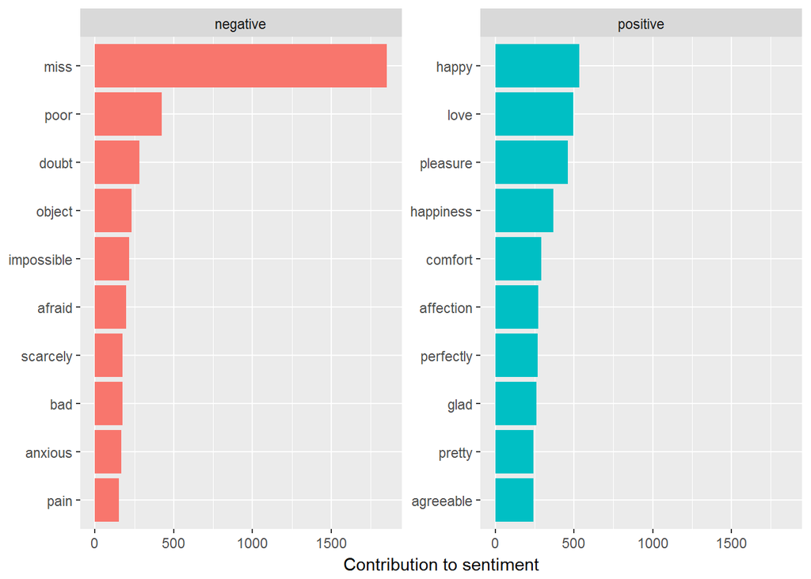

```r
#Now lets plot it
bing_word_counts %>%
  group_by(sentiment) %>%
  top_n(10) %>%
  ungroup() %>%
  mutate(word = reorder(word, n)) %>%
  ggplot(aes(word, n, fill = sentiment)) +
  geom_col(show.legend = FALSE) +
  facet_wrap(~sentiment, scales = "free_y") +
  labs(y = "Contribution to sentiment",
       x = NULL) +
  coord_flip()
```

## Custom Stop-word

We can see an anomaly related to the word “miss” –it is coded as negative but it is used as a title for young, unmarried women in Jane Austen’s works. We can add “miss” to a custom stop-words list using `bind_rows()`:

```r
custom_stop_words <- bind_rows(data_frame(word = c("miss"),
                                          lexicon = c("custom")),
                               stop_words)

custom_stop_words
```

```
## # A tibble: 1,150 x 2
##    word        lexicon
##    <chr>       <chr>
##  1 miss        custom
##  2 a           SMART
##  3 a's         SMART
##  4 able        SMART
##  5 about       SMART
##  6 above       SMART
##  7 according   SMART
##  8 accordingly SMART
##  9 across      SMART
## 10 actually    SMART
## # ... with 1,140 more rows
```

## Wordclouds

Wordclouds can be made using the package `wordcloud`.

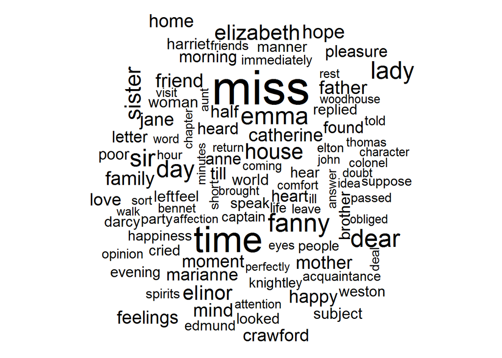

```r
tidy_books %>%
  anti_join(stop_words) %>%
  count(word) %>%
  with(wordcloud(word, n, max.words = 100))
```

Most common positive and negative words in Jane Austen’s novels

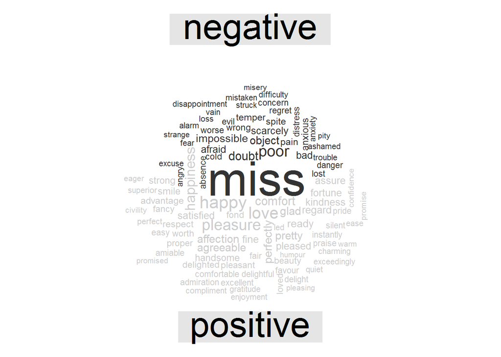

```r
tidy_books %>%
  inner_join(get_sentiments("bing")) %>%
  count(word, sentiment, sort = TRUE) %>%
  acast(word ~ sentiment, value.var = "n", fill = 0) %>%
  comparison.cloud(colors = c("gray20", "gray80"),
                   max.words = 100)
```

## Sentences

Some sentiment analysis algorithms look beyond only unigrams (i.e. single words) to try to understand the sentiment of a sentence as a whole. These algorithms try to understand that

I am not having a good day.

is a sad sentence, not a happy one, because of negation.

R packages such as coreNLP (T. Arnold and Tilton 2016), cleanNLP (T. B. Arnold 2016), and sentimentr (Rinker 2017) are examples of such sentiment analysis algorithms. For these, we may want to tokenize text into sentences, and it makes sense to use a new name for the output column in such a case.

[Sentimentr package](https://cran.r-project.org/web/packages/sentimentr/README.html)

# Resources

- [Gaston Sanchez, Handling and Processing Strings in R](http://www.gastonsanchez.com/Handling_and_Processing_Strings_in_R.pdf)
- [Stat545 Tutorial: Regular Expression in R](http://stat545.com/block022_regular-expression.html)
- [Svetlana Eden, Introduction to String Matching and Modification in R Using Regular Expressions](http://biostat.mc.vanderbilt.edu/wiki/pub/Main/SvetlanaEdenRFiles/regExprTalk.pdf)
- [Tidytext Mining with R](https://www.tidytextmining.com)
- [Data Science 101: Sentiment Analysis in R Tutorial](http://blog.kaggle.com/2017/10/05/data-science-101-sentiment-analysis-in-r-tutorial/)